# turismo2

## Introdução

O turismo é um ativo econômico muito importante para diversos lugares no Brasil e para a própria economia nacional. Para Balaguer e Cantavella-Jordá (2002), expandir o turismo internacional pode promover crescimentos econômicos duradouros. A industria de turismo gera trocas econômicas significativas, estimular investimos, criar trabalhos, e desta forma aumentar a renda da população (Brida, 2014). Compreender os fluxos de turistas internacionais durante as épocas do ano em diferentes regiões é de suma importância para o planejamento adiantado do direcionamento desses investimentos tanto públicos quanto privados na área de turismo. As amostras analisadas foram feitas pelo Ministério do Turismo e representa o fluxo de chegadas de turistas internacionais (incluem turistas estrangeiros e brasileiros que residem no exterior), desagregadas por país de residência permanente, por mês e via de acesso (aérea, terrestre, marítima ou fluvial) no Brasil durante os anos de 2013 até 2023. O objetivo do seguinte trabalho é fazer uma análise exploratória da chegada desses turistas nas regiões Sul e Nordeste, utilizando gráficos, métricas estatísticas e referencias bibliográficas, além desenvolver ideias iniciais acerca do aumento do fluxo de turistas internacionais nessas regiões nos meses de inverno e verão, considerando as estações no Brasil, por meio de ferramentas de estatística inferencial como testes de hipótese, utilizando o método bootstrap. Por fim, será possível chegar a conclusões mais precisas acerca de quais características podem ser mais importantes no aumento ou decrescimento no número de turistas em cada região, fornecendo idéias para projetos futuros.

## Importação das bibliotecas

```python
import pandas as pd
import matplotlib.pyplot as plt
import numpy as np
from scipy.stats import shapiro
from scipy import stats
from sklearn.utils import resample
from statsmodels.tsa.seasonal import seasonal_decompose
from statsmodels.graphics.tsaplots import plot_acf
from statsmodels.tsa.stattools import adfuller
from statsmodels.tsa.arima.model import ARIMA
from statsmodels.tsa.statespace.sarimax import SARIMAX
from pmdarima import auto_arima
from sklearn.preprocessing import MinMaxScaler
from tensorflow.keras.models import Sequential
from tensorflow.keras.layers import LSTM, Dense, Dropout
from tensorflow.keras.optimizers import Adam
import tensorflow as tf
from scipy import stats
from sklearn.metrics import r2_score, mean_squared_error, mean_absolute_error
```

## Carregando as bases de dados do Ministério do Turismo

Como as bases de dados são disponibilizados separadamente por ano é preciso fazer a junção delas. As váriaveis de código não vão ser utilizadas e tanto o ano de 2023 quanto os anos anteriores a 2016 utilizam uma padronização diferente nos nomes das váriaveis.

```python
#Foi preferido fazer uma função para junção dos bancos, pois caso seja necessário adicionar mais bancos de outros anos isso
#já vai ser feito de forma automática
def concatDB(anos):
    df = pd.read_csv("chegadas_2023.csv", encoding="ANSI", delimiter=";")
    df.drop(columns=['cod pais', 'cod continente', 'cod uf', 'cod via', 'cod mes'], inplace=True)

    for ano in anos:
        nome_arq = f"chegadas_{ano}.csv"
        df_concat = pd.read_csv(nome_arq, encoding="ANSI", delimiter=";")
        df_concat.rename(columns={"País": "Pais", "Mês": "Mes", "ano": "Ano"}, inplace=True)
        if ano < 2016:
            df_concat.drop(columns=["Ordem continente", "Ordem país", "Ordem UF", "Ordem via de acesso", "Ordem mês"], inplace=True)
            df_concat.rename(columns={"Via de acesso": "Via"}, inplace=True)
        else:
            df_concat.drop(columns=['cod pais', 'cod continente', 'cod uf', 'cod via', 'cod mes'], inplace=True)

        df_concat['Via'] = df_concat['Via'].str.replace("Marítima", "Marítimo")
        df_concat['Via'] = df_concat['Via'].str.replace("Aérea", "Aéreo")
        df_concat['Mes'] = df_concat['Mes'].str.capitalize()
        df_concat['Mes'] = df_concat['Mes'].str.replace("Março", "Marco")
        df = pd.concat([df, df_concat])
    return df
```

```python
anos = [2022, 2021, 2020, 2019, 2018, 2017, 2016, 2015, 2014, 2013]
df = concatDB(anos)
#O index permanece o mesmo após a junção, por isso é preciso reseta-lo
df = df.reset_index(drop=True)
df
```

|  | Continente | Pais | UF | Via | Ano | Mes | Chegadas |
| --- | --- | --- | --- | --- | --- | --- | --- |
| 0 | América do Sul | Peru | Acre | Aéreo | 2023 | Novembro | 0.0 |
| 1 | América do Sul | Peru | Acre | Aéreo | 2023 | Novembro | 0.0 |
| 2 | Ásia | Outros países | Outras Unidades da Federação | Aéreo | 2023 | Junho | 0.0 |
| 3 | Europa | Alemanha | Outras Unidades da Federação | Aéreo | 2023 | Janeiro | 12.0 |
| 4 | Europa | Alemanha | Outras Unidades da Federação | Aéreo | 2023 | Fevereiro | 10.0 |
| ... | ... | ... | ... | ... | ... | ... | ... |
| 472627 | Europa | Outros países | Outras Unidades da Federação | Fluvial | 2013 | Dezembro | 8.0 |
| 472628 | Oceania | Austrália | Outras Unidades da Federação | Fluvial | 2013 | Dezembro | 2.0 |
| 472629 | Oceania | Nova Zelândia | Outras Unidades da Federação | Fluvial | 2013 | Dezembro | 0.0 |
| 472630 | Oceania | Outros países | Outras Unidades da Federação | Fluvial | 2013 | Dezembro | 0.0 |
| 472631 | Continente não especificado | Países não especificados | Outras Unidades da Federação | Fluvial | 2013 | Dezembro | 0.0 |

472632 rows × 7 columns

## Análise da base de dados concatenada

```python
df.shape
```

```
(472632, 7)
```

```python
df.info()
```

```
<class 'pandas.core.frame.DataFrame'>
RangeIndex: 472632 entries, 0 to 472631
Data columns (total 7 columns):
 #   Column      Non-Null Count   Dtype
---  ------      --------------   -----
 0   Continente  472632 non-null  object
 1   Pais        472632 non-null  object
 2   UF          472632 non-null  object
 3   Via         472632 non-null  object
 4   Ano         472632 non-null  int64
 5   Mes         472632 non-null  object
 6   Chegadas    471960 non-null  float64
dtypes: float64(1), int64(1), object(5)
memory usage: 25.2+ MB
```

Verificando se existe valores ausentes

```python
df.isnull().sum()
```

```
Continente      0
Pais            0
UF              0
Via             0
Ano             0
Mes             0
Chegadas      672
dtype: int64
```

```python
df['Chegadas'] = df['Chegadas'].fillna(0)
```

```python
df.isnull().values.any()
```

```
False
```

```python
df['Via'].unique()
```

```
array(['Aéreo', 'Terrestre', 'Marítimo', 'Fluvial'], dtype=object)
```

```python
df['Continente'].unique()
```

```
array(['América do Sul', 'Ásia', 'Europa', 'Oceania', 'África',
       'América do Norte', 'América Central e Caribe',
       'Continente não especificado'], dtype=object)
```

```python
df['UF'].unique()
```

```
array(['Acre', 'Outras Unidades da Federação', 'Amapá', 'Amazonas',
       'Bahia', 'Ceará', 'Distrito Federal', 'Mato Grosso do Sul',
       'Minas Gerais', 'Pará', 'Paraná', 'Pernambuco', 'Rio de Janeiro',
       'Rio Grande do Norte', 'Rio Grande do Sul', 'Roraima',
       'Santa Catarina', 'São Paulo'], dtype=object)
```

Alguns estados não estão incluídos, na região Nordeste, por exemplo, estão faltando 5 estados. Não foi encontrado nada oficial, mas possivelmente foi por conta do tipo de amostragem.

```python
df['Mes'].unique()
```

```
array(['Novembro', 'Junho', 'Janeiro', 'Fevereiro', 'Marco', 'Abril',
       'Maio', 'Julho', 'Agosto', 'Setembro', 'Outubro', 'Dezembro'],
      dtype=object)
```

```python
#É preciso mudar o tipo das váriaveis
df.dtypes
```

```
Continente     object
Pais           object
UF             object
Via            object
Ano             int64
Mes            object
Chegadas      float64
dtype: object
```

Mudando os tipos de váriaveis

```python
df['Continente'] = df['Continente'].astype('category')
df['Pais'] = df['Pais'].astype('category')
df['Via'] = df['Via'].astype('category')
df['Ano'] = df['Ano'].astype('int')
df['Mes'] = df['Mes'].astype('category')
df['UF'] = df['UF'].astype('string')
```

```python
df.dtypes
```

```
Continente          category
Pais                category
UF            string[python]
Via                 category
Ano                    int32
Mes                 category
Chegadas             float64
dtype: object
```

## Filtrando a base dados para as regiões Sul e Nordeste

Relembrando que na região Nordeste os estados de Alagoas, Maranhão, Paraíba, Sergipe e Piauí não estão especificados.

```python
estados_nordeste = ["Bahia", "Ceará", "Pernambuco", "Rio Grande do Norte"]
estados_sul = ["Paraná", "Santa Catarina", "Rio Grande do Sul"]
```

```python
df_nordeste = df[df['UF'].isin(estados_nordeste)]
df_nordeste = df_nordeste.reset_index(drop=True)
df_nordeste
```

|  | Continente | Pais | UF | Via | Ano | Mes | Chegadas |
| --- | --- | --- | --- | --- | --- | --- | --- |
| 0 | Ásia | Outros países | Bahia | Aéreo | 2023 | Setembro | 1.0 |
| 1 | África | África do Sul | Bahia | Aéreo | 2023 | Novembro | 0.0 |
| 2 | África | África do Sul | Bahia | Aéreo | 2023 | Novembro | 0.0 |
| 3 | Europa | Alemanha | Bahia | Aéreo | 2023 | Abril | 0.0 |
| 4 | Europa | Alemanha | Bahia | Aéreo | 2023 | Novembro | 0.0 |
| ... | ... | ... | ... | ... | ... | ... | ... |
| 87963 | Europa | Outros países | Rio Grande do Norte | Marítimo | 2013 | Dezembro | 2.0 |
| 87964 | Oceania | Austrália | Rio Grande do Norte | Marítimo | 2013 | Dezembro | 1.0 |
| 87965 | Oceania | Nova Zelândia | Rio Grande do Norte | Marítimo | 2013 | Dezembro | 0.0 |
| 87966 | Oceania | Outros países | Rio Grande do Norte | Marítimo | 2013 | Dezembro | 0.0 |
| 87967 | Continente não especificado | Países não especificados | Rio Grande do Norte | Marítimo | 2013 | Dezembro | 0.0 |

87968 rows × 7 columns

```python
df_sul = df[df['UF'].isin(estados_sul)]
df_sul = df_sul.reset_index(drop=True)
df_sul
```

|  | Continente | Pais | UF | Via | Ano | Mes | Chegadas |
| --- | --- | --- | --- | --- | --- | --- | --- |
| 0 | África | África do Sul | Paraná | Aéreo | 2023 | Fevereiro | 2.0 |
| 1 | África | África do Sul | Paraná | Aéreo | 2023 | Abril | 0.0 |
| 2 | África | África do Sul | Paraná | Aéreo | 2023 | Maio | 1.0 |
| 3 | África | África do Sul | Paraná | Aéreo | 2023 | Junho | 0.0 |
| 4 | África | África do Sul | Paraná | Aéreo | 2023 | Julho | 0.0 |
| ... | ... | ... | ... | ... | ... | ... | ... |
| 118425 | Europa | Outros países | Rio Grande do Sul | Fluvial | 2013 | Dezembro | 0.0 |
| 118426 | Oceania | Austrália | Rio Grande do Sul | Fluvial | 2013 | Dezembro | 0.0 |
| 118427 | Oceania | Nova Zelândia | Rio Grande do Sul | Fluvial | 2013 | Dezembro | 1.0 |
| 118428 | Oceania | Outros países | Rio Grande do Sul | Fluvial | 2013 | Dezembro | 0.0 |
| 118429 | Continente não especificado | Países não especificados | Rio Grande do Sul | Fluvial | 2013 | Dezembro | 0.0 |

118430 rows × 7 columns

## Análise exploratória dos dados na região Nordeste

Análise das váriaveis considerando o período de 2013 a 2023

Importante destacar que algumas teses propostas por essas análises precisariam de testes de inferência para maior embasamento, já que se trata de uma amostragem.

```python
df_nordeste['UF'].value_counts()
```

```
UF
Bahia                  22397
Pernambuco             22274
Ceará                  21984
Rio Grande do Norte    21313
Name: count, dtype: Int64
```

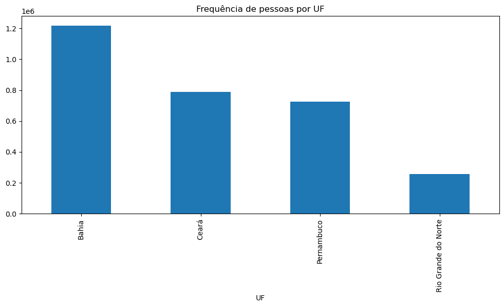

```python
fluxo_tur = df_nordeste.groupby("UF")['Chegadas'].sum()
fluxo_tur.plot(kind = 'bar', figsize=(12,5))
plt.title("Frequência de pessoas por UF")
```

A frequência de turistas parece ter alguma ligação com a população de cada estado. Utilizando o teste de correlação é obtido o seguinte resultado:

```python
pop = pd.Series([14.141, 9.2, 9.5, 3.446], index=['Bahia', 'Ceará', 'Pernambuco', "Rio Grande do Norte"])
df_pop_tur = pd.DataFrame({"População": pop, "Turistas": fluxo_tur})
corr = df_pop_tur.corr()
corr.style.background_gradient()
```

|  | População | Turistas |
| --- | --- | --- |
| População | 1.000000 | 0.994419 |
| Turistas | 0.994419 | 1.000000 |

0.99 indica uma correlação proporcional forte das duas váriaveis, ou seja, a quantidade turistas é diretamente proporcional a população nesses estados. Fazer essa correlação com todos os estados do Brasil presentes na amostra seria interessante em incrementos futuros.

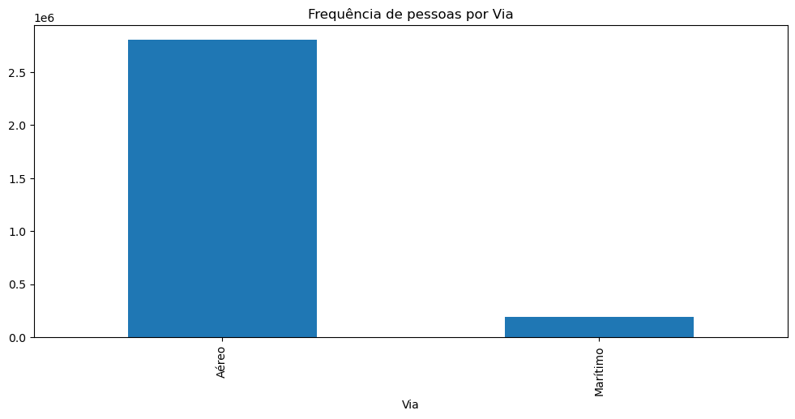

```python
df_nordeste.groupby("Via", observed=True)['Chegadas'].sum().plot(kind = 'bar', figsize=(12,5))
plt.title("Frequência de pessoas por Via")
```

Não existe registros de turistas internacionais utilizando a via fluvial ou terreste, isso deve ao fato de que a região Nordeste não faz divisa com nenhum outro país o que impede a utilização dessas vias.

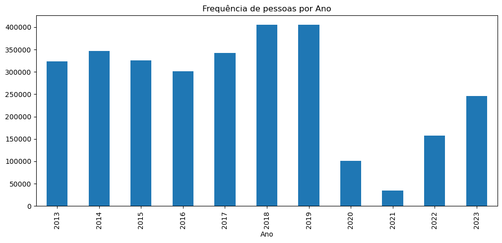

```python
df_nordeste.groupby("Ano", observed=True)['Chegadas'].sum().plot(kind = 'bar', figsize=(12,5))
plt.title("Frequência de pessoas por Ano")
```

A frequência de turistas internacionais entre os anos de 2020 e 2022 diminuiu drasticamente por conta da pandemia e atualmente teve uma recuperação mais lenta quando comparada com a região Sul. De acordo com ROGERSON (2020, p.6), no momento pós pandemia, o turismo doméstico, caracterizado como viagens mais próximas e locais, levando em conta a proximidade geografica e cultural, acabou se tornando mais preferido. Uma das razões para esse comportamento é a ameaça de doenças, essas ameaças despertam atitudes mais "coletivistas" o que se aplica também a área de turismo. Como já observado, a região Nordeste não tem fronteira com outros países da America do Sul, o tornando menos atrativo para esses visitantes domésticos. Essa situação se agrava quando consideramos viagens internacionais em longas distâncias, pois essas viagens correspondem ao perfil da maioria dos turistas europeus. Eles representam uma parte significativa dos turistas internacionais do Nordeste, afetando consideravelmente a quantidade de turistas no período pós pandemia.

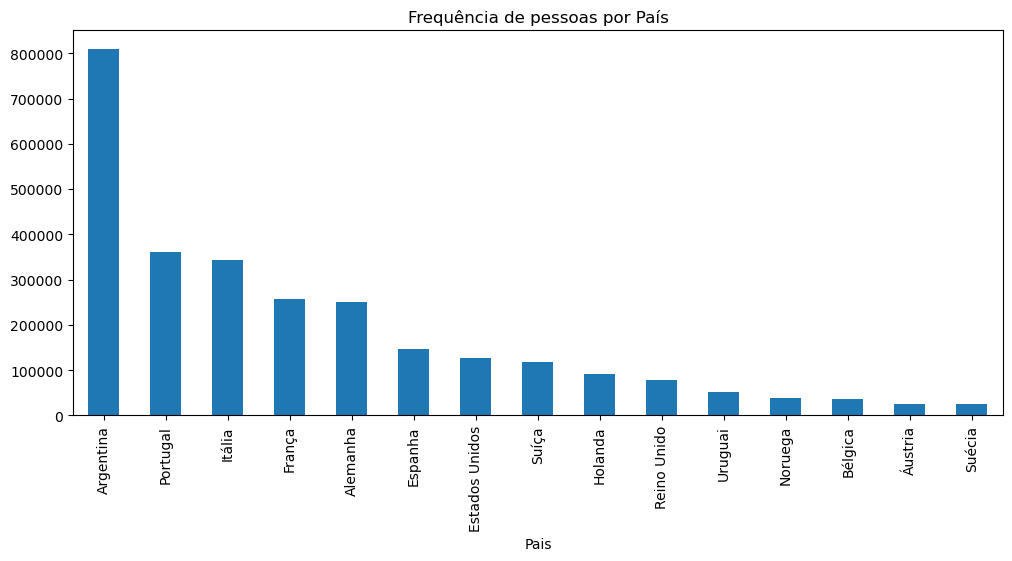

```python
df_nordeste.groupby("Pais", observed=True)['Chegadas'].sum().sort_values(ascending=False).head(15).plot(kind = 'bar', figsize=(12,5))
plt.title("Frequência de pessoas por País")
```

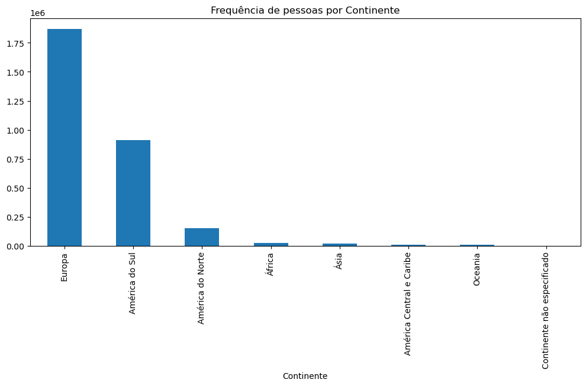

```python
df_nordeste.groupby("Continente", observed=True)['Chegadas'].sum().sort_values(ascending=False).head(15).plot(kind = 'bar', figsize=(12,5))
plt.title("Frequência de pessoas por Continente")
```

A maior parte dos turistas da América do Sul vem da Argentina. A quantidade de turistas de outros países desse continente é bem baixo, o que reforça menor atratividade de turistas que a região Nordeste tem com os países vizinhos, principalmente quando comparado com a região Sul,.

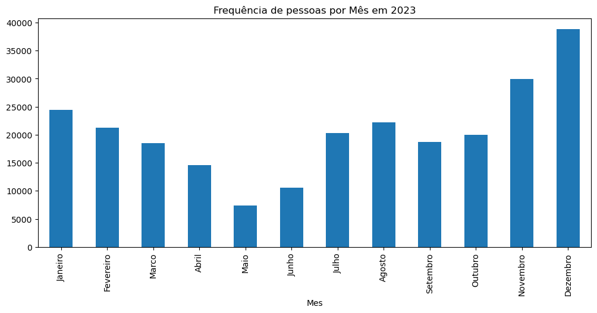

```python
df_nordeste_2023 = df_nordeste[df_nordeste['Ano'] == 2023]
ordem_meses = [
    "Janeiro", "Fevereiro", "Marco", "Abril", "Maio", "Junho",
    "Julho", "Agosto", "Setembro", "Outubro", "Novembro", "Dezembro"
]
quant_mes = df_nordeste_2023.groupby("Mes", observed=True)['Chegadas'].sum()
#Orderna os index da serie com base no vetor ordem_MESES
quant_mes.index = pd.CategoricalIndex(quant_mes.index, categories=ordem_meses, ordered=True)
quant_mes = quant_mes.sort_index()

quant_mes.plot(kind = 'bar', figsize=(12,5))
plt.title("Frequência de pessoas por Mês em 2023")
```

Existe um grande fluxo de turistas no verão e no inverno, porém no verão o fluxo vai diminuindo ao decorrer dos meses e no inverno o processo é inverso. Os europeus que compõem boa parte dos turistas em ambas as estações, como vemos nos gráficos abaixo, tem férias mais longas no inverno do Brasil o que poder ser um dos fatores que explica esse fenômeno. Obviamente, existem outros perfis importantes de turistas, como os Argentinos, que tem comportamentos gerais mais distintos.

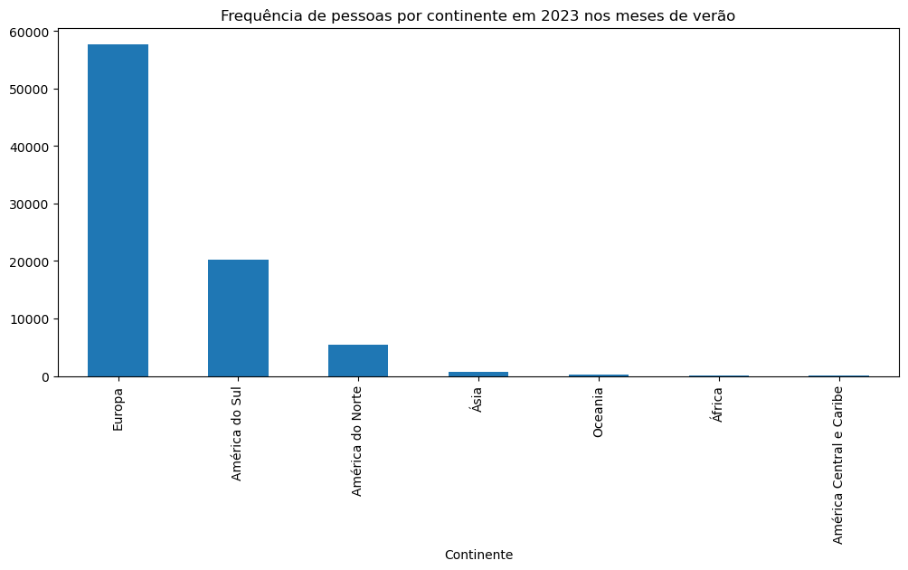

```python
meses_verao = ["Dezembro", "Janeiro", "Fevereiro"]
df_nordeste_2023_ver = df_nordeste_2023[df_nordeste_2023['Mes'].isin(meses_verao)]
df_nordeste_2023_ver.groupby("Continente", observed=True)['Chegadas'].sum().sort_values(ascending=False).head(10).plot(kind = "bar", figsize=(12,5))
plt.title("Frequência de pessoas por continente em 2023 nos meses de verão")
```

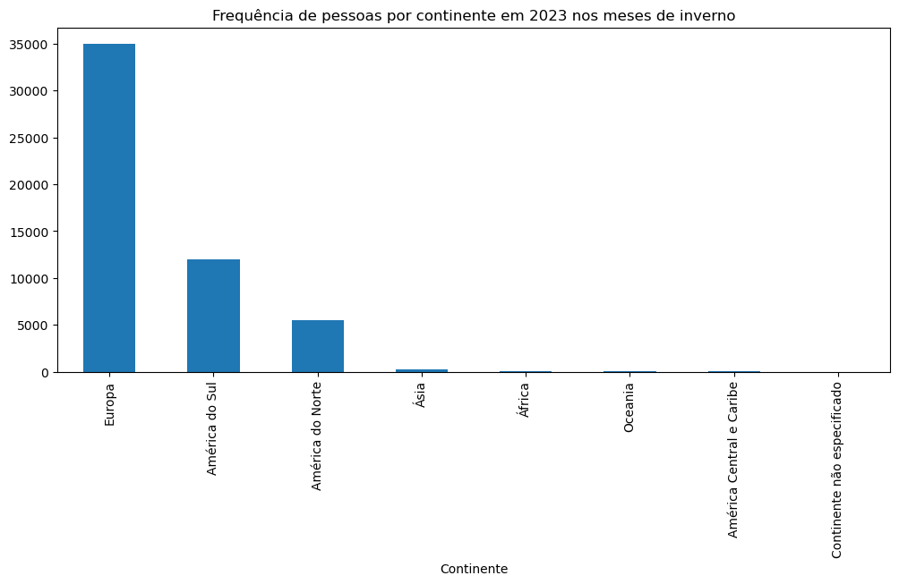

```python
meses_inverno = ["Junho", "Julho", "Agosto"]
df_nordeste_2023_inv = df_nordeste_2023[df_nordeste_2023['Mes'].isin(meses_inverno)]
df_nordeste_2023_inv.groupby("Continente", observed=True)['Chegadas'].sum().sort_values(ascending=False).head(10).plot(kind = "bar", figsize=(12,5))
plt.title("Frequência de pessoas por continente em 2023 nos meses de inverno")
```

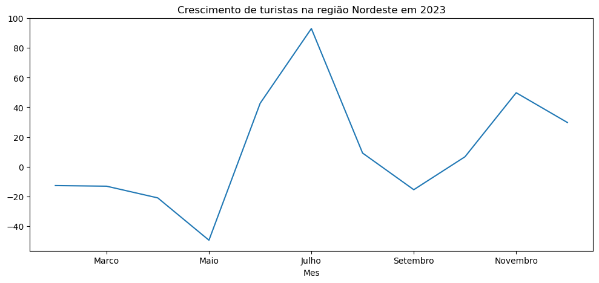

```python
porct_mensal = quant_mes.pct_change() * 100
porct_mensal.plot(figsize=(12,5))
plt.title("Crescimento de turistas na região Nordeste em 2023")
```

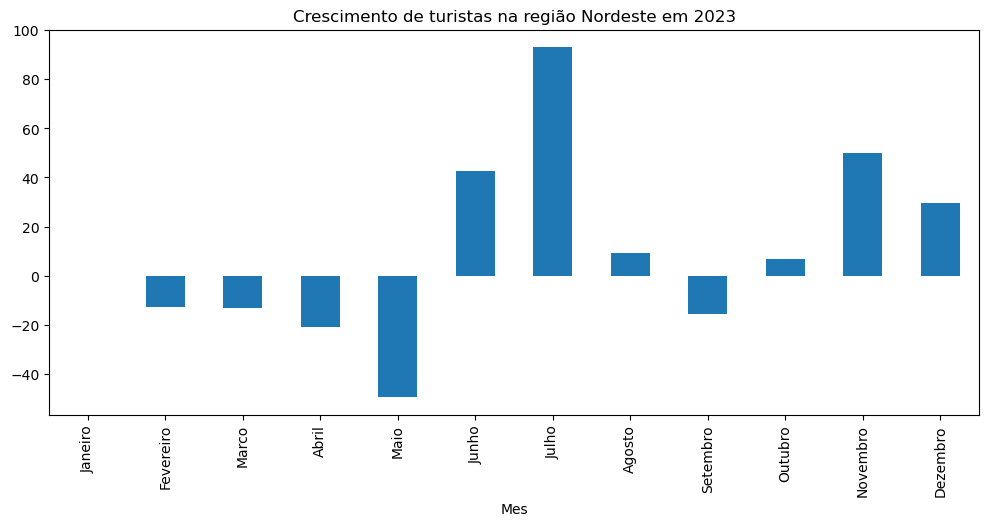

```python
porct_mensal.plot(kind="bar", figsize=(12,5))
plt.title("Crescimento de turistas na região Nordeste em 2023")
```

O crescimento nos meses de inverno nesse ano parece ser muitor maior comparado com os meses de verão sem considerar Janeiro. A partir da média de crescimento dessas estações considerando o período de 2013 até 2023 será possível obter uma análise mais precisa.

```python
sum_meses = np.zeros((12, 10))
sum_meses_seq = np.zeros((120,))
x = 0
i = 0
dezembro = None
for ano in anos:
    df_nordeste_ano = df_nordeste[df_nordeste['Ano'] == ano]
    quant_mes = df_nordeste_ano.groupby("Mes", observed=True)['Chegadas'].sum()
    quant_mes.index = pd.CategoricalIndex(quant_mes.index, categories=ordem_meses, ordered=True)
    quant_mes = quant_mes.sort_index()
    pct_mes = quant_mes.pct_change()
    j = 0
    for mes in pct_mes:
        #Caso seja janeiro é necessário atribuir o crescimento manualmente
        if (j == 0):
            #Se for o primeiro registro, ou seja, Janeiro de 2013
            if (dezembro is None):
                j += 1
                x += 1
                continue
            crs_jan = ((quant_mes["Janeiro"] - dezembro) / dezembro)
            sum_meses[j][i] = crs_jan
            sum_meses_seq[x] = crs_jan
            j += 1
            x += 1
            continue
        sum_meses[j][i] = mes
        sum_meses_seq[x] = mes
        if (j == 11):
            dezembro = quant_mes["Dezembro"]
        j += 1
        x += 1
    i += 1
sum_meses
```

```
array([[ 0.00000000e+00, -8.95776154e-01,  3.32221731e+00,
         9.44902186e+00, -1.42906688e-01, -3.93641505e-01,
        -7.93011670e-02, -1.64544143e-01, -3.33629532e-01,
        -2.02800518e-01],
       [ 7.93348566e-02, -9.72640219e-01, -5.36763579e-02,
        -3.99991190e-02, -1.15906843e-01, -1.28019537e-01,
        -3.19916982e-01, -5.50336384e-02, -7.61247681e-02,
        -1.54994968e-01],
       [-5.92731977e-02, -8.50000000e-01, -6.29653627e-01,
        -3.46357692e-01, -1.33467250e-01, -1.67498988e-01,
        -1.08955495e-01, -7.05535245e-03, -3.92155632e-01,
        -2.23238693e-01],
       [ 5.12939117e-01,  2.87500000e+01, -9.99271031e-01,
        -2.99062796e-02, -3.49364711e-01, -3.89915694e-02,
        -3.64184947e-01, -5.42019249e-01, -1.82737972e-02,
        -3.98341406e-01],
       [-5.59742191e-01,  7.95518207e-01, -5.00000000e-01,
        -4.48710063e-01, -3.70721147e-01, -3.30198229e-01,
        -2.78504553e-01, -1.49365303e-01, -3.94205490e-01,
        -2.52794348e-01],
       [ 4.41441441e-01,  1.06084243e-01,  5.00000000e+00,
         4.53793647e-01,  1.54590411e-01,  1.15861722e-02,
         1.43631677e-01,  3.79124523e-01,  4.37297110e+00,
         3.09409394e-01],
       [ 8.09505208e-01,  2.48377997e+00,  4.76666667e+00,
         4.69571106e-01,  9.51520795e-01,  8.52972300e-01,
         7.40809824e-01,  5.87015329e-01, -6.37346128e-01,
         2.88031254e-01],
       [ 1.18730661e-01, -2.28744939e-01,  2.46820809e+00,
         1.40456514e-01,  5.67766150e-02, -1.25167966e-01,
         5.00022322e-02, -8.23863636e-02, -9.85790013e-02,
         1.85569853e-01],
       [-1.54049013e-01, -6.82414698e-03,  1.75000000e-01,
        -1.91040595e-01,  6.67288707e-02,  8.99316489e-02,
         2.50010630e-02, -3.43653251e-01, -1.69450484e-01,
        -4.19644934e-01],
       [ 2.02630779e-01,  2.68974630e+00,  2.53333333e+00,
        -6.23688855e-02,  6.96932931e-03,  1.90952649e-02,
         1.98987846e-01,  9.48113208e-01,  3.37240436e-01,
         7.06051296e-01],
       [ 3.32869697e-01,  3.40925369e-02,  1.67001204e-01,
         5.15981249e-01,  2.30889935e-01,  4.21869598e-01,
         7.08206477e-02,  2.23470541e-01,  4.14060067e-01,
         3.46357123e-01],
       [ 3.30756095e-01,  2.54467378e-01,  4.94668043e-01,
         2.15850259e-01,  2.75974322e-01,  6.88078971e-02,
         2.76113857e-01,  3.65992031e-01,  7.25779554e-01,
         3.12096540e-01]])
```

```python
sum_meses_seq
```

```
array([ 0.00000000e+00,  7.93348566e-02, -5.92731977e-02,  5.12939117e-01,
       -5.59742191e-01,  4.41441441e-01,  8.09505208e-01,  1.18730661e-01,
       -1.54049013e-01,  2.02630779e-01,  3.32869697e-01,  3.30756095e-01,
       -8.95776154e-01, -9.72640219e-01, -8.50000000e-01,  2.87500000e+01,
        7.95518207e-01,  1.06084243e-01,  2.48377997e+00, -2.28744939e-01,
       -6.82414698e-03,  2.68974630e+00,  3.40925369e-02,  2.54467378e-01,
        3.32221731e+00, -5.36763579e-02, -6.29653627e-01, -9.99271031e-01,
       -5.00000000e-01,  5.00000000e+00,  4.76666667e+00,  2.46820809e+00,
        1.75000000e-01,  2.53333333e+00,  1.67001204e-01,  4.94668043e-01,
        9.44902186e+00, -3.99991190e-02, -3.46357692e-01, -2.99062796e-02,
       -4.48710063e-01,  4.53793647e-01,  4.69571106e-01,  1.40456514e-01,
       -1.91040595e-01, -6.23688855e-02,  5.15981249e-01,  2.15850259e-01,
       -1.42906688e-01, -1.15906843e-01, -1.33467250e-01, -3.49364711e-01,
       -3.70721147e-01,  1.54590411e-01,  9.51520795e-01,  5.67766150e-02,
        6.67288707e-02,  6.96932931e-03,  2.30889935e-01,  2.75974322e-01,
       -3.93641505e-01, -1.28019537e-01, -1.67498988e-01, -3.89915694e-02,
       -3.30198229e-01,  1.15861722e-02,  8.52972300e-01, -1.25167966e-01,
        8.99316489e-02,  1.90952649e-02,  4.21869598e-01,  6.88078971e-02,
       -7.93011670e-02, -3.19916982e-01, -1.08955495e-01, -3.64184947e-01,
       -2.78504553e-01,  1.43631677e-01,  7.40809824e-01,  5.00022322e-02,
        2.50010630e-02,  1.98987846e-01,  7.08206477e-02,  2.76113857e-01,
       -1.64544143e-01, -5.50336384e-02, -7.05535245e-03, -5.42019249e-01,
       -1.49365303e-01,  3.79124523e-01,  5.87015329e-01, -8.23863636e-02,
       -3.43653251e-01,  9.48113208e-01,  2.23470541e-01,  3.65992031e-01,
       -3.33629532e-01, -7.61247681e-02, -3.92155632e-01, -1.82737972e-02,
       -3.94205490e-01,  4.37297110e+00, -6.37346128e-01, -9.85790013e-02,
       -1.69450484e-01,  3.37240436e-01,  4.14060067e-01,  7.25779554e-01,
       -2.02800518e-01, -1.54994968e-01, -2.23238693e-01, -3.98341406e-01,
       -2.52794348e-01,  3.09409394e-01,  2.88031254e-01,  1.85569853e-01,
       -4.19644934e-01,  7.06051296e-01,  3.46357123e-01,  3.12096540e-01])
```

Para calcular a média de crescimento, a média geometrica será mais adequada, já que considera as variações percentuais, incluindo períodos de crescimento e decrescimento.

```python
#O número 1 é o fator multiplicativo que serve para evitar que os valores sejam negativos, pois a média geométrica só aceita
#números positivos
dezembro = 1 + sum_meses[11]
janeiro = 1 + sum_meses[0]
fevereiro = 1 + sum_meses[1]
produto_tot = dezembro.prod() * janeiro.prod() * fevereiro.prod()
media_geometrica = produto_tot ** (1 / 30)
media_crescimento = (media_geometrica - 1) * 100
media_crescimento
```

```
-5.746825833039104
```

A média de crescimento de turistas internacionais nos meses de verão na região Nordeste é de aproximadamente -5.75%

```python
junho = 1 + sum_meses[5]
julho = 1 + sum_meses[6]
agosto = 1 + sum_meses[7]
produto_tot = junho.prod() * julho.prod() * agosto.prod()
media_geometrica = produto_tot ** (1 / 30)
media_crescimento = (media_geometrica - 1) * 100
media_crescimento
```

```
48.64249024877279
```

A média de crescimento de turistas internacionais nos meses de inverno na região Nordeste é de aproximadamente 48.64%

De fato a média de crescimento na estação do verão é muito menor em comparação com o inverno.

Abaixo foi utilizado a abordagem de logaritmos que será útil quando os testes de hipotese forem aplicados

```python
#O np.log transforma em logaritimos naturais
log_nord_verao = np.concatenate((np.log(dezembro), np.log(janeiro), np.log(fevereiro)))
media_aritmetica = np.mean(log_nord_verao)
valor_log = np.exp(media_aritmetica)
media_geometrica = valor_log - 1
media_geometrica * 100
```

```
-5.746825833039104
```

Portanto, a média aritmética dos dados transformados em log é correspondente ao log da média geometrica dos dados originais

```python
#Guardando os dados transformados em log para o teste de hipótese
log_nord_inverno = np.concatenate((np.log(junho), np.log(julho), np.log(agosto)))
```

## Análise exploratória dos dados na região Sul

```python
df_sul['UF'].value_counts()
```

```
UF
Rio Grande do Sul    44550
Santa Catarina       37756
Paraná               36124
Name: count, dtype: Int64
```

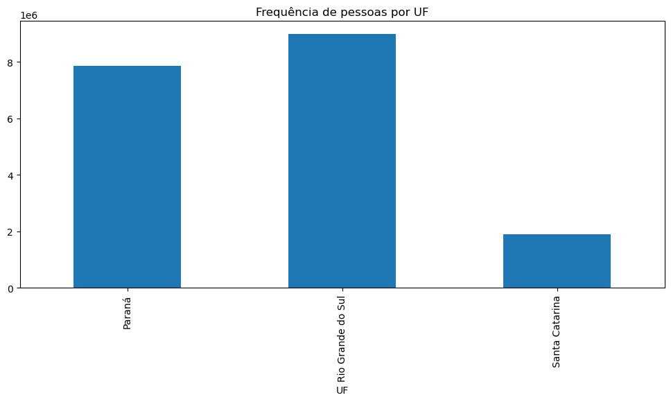

```python
fluxo_tur = df_sul.groupby("UF")['Chegadas'].sum()
fluxo_tur.plot(kind = 'bar', figsize=(12,5))
plt.title("Frequência de pessoas por UF")
```

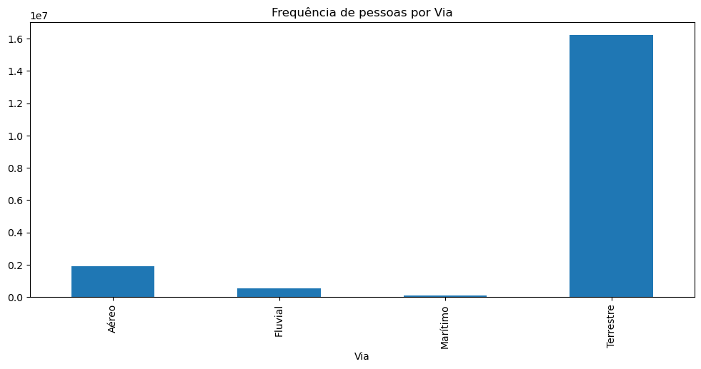

```python
df_sul.groupby("Via", observed=True)['Chegadas'].sum().plot(kind = 'bar', figsize=(12,5))
plt.title("Frequência de pessoas por Via")
```

Em comparação com a região Nordeste, a região Sul possui uma variedade maior de vias.

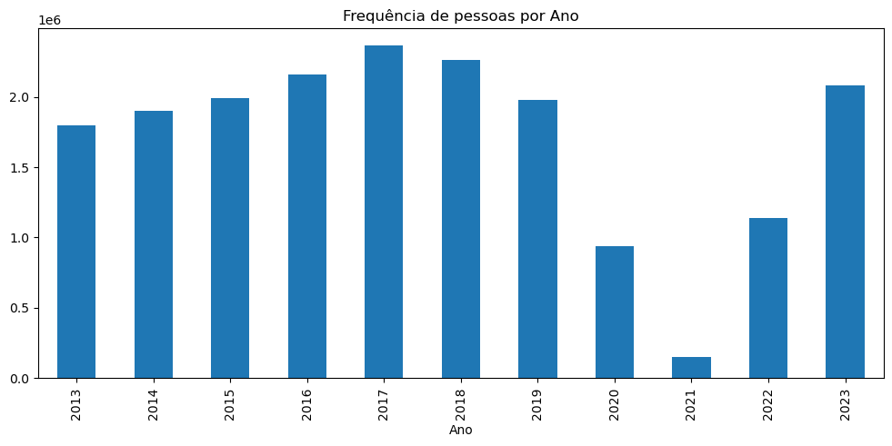

```python
df_sul.groupby("Ano", observed=True)['Chegadas'].sum().plot(kind = 'bar', figsize=(12,5))
plt.title("Frequência de pessoas por Ano")
```

Nota-se que houve uma queda considerável no periodo da pandemia de COVID assim como na região Nordeste, porém a recuperação do número de turistas em 2023 é maior quando comparado com o mesmo ano no Nordeste. O fato da maioria dos turistas internacionais estarem em países vizinhos, como é possível ver nos gráficos abaixo, pode ter uma grande contribuição nesse fenômeno, já que atrela a percepção desses turistas acerca dos estados do Sul com viagens domésticas.

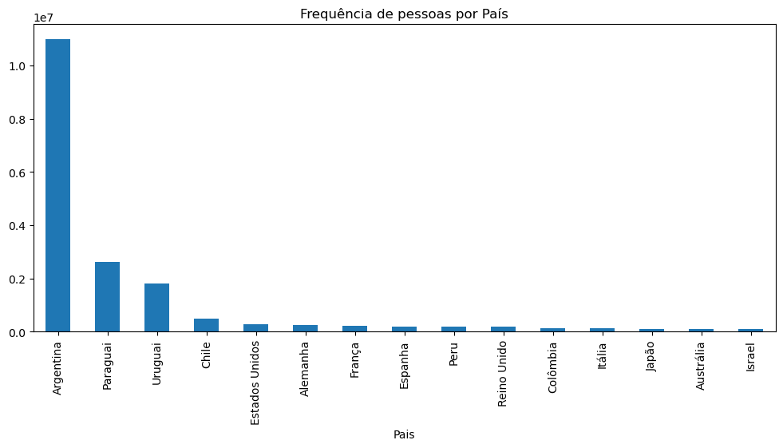

```python
df_sul.groupby("Pais", observed=True)['Chegadas'].sum().sort_values(ascending=False).head(15).plot(kind = 'bar', figsize=(12,5))
plt.title("Frequência de pessoas por País")
```

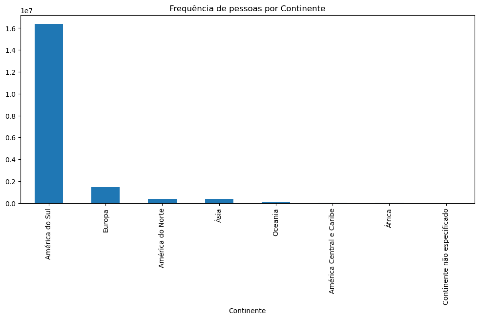

```python
df_sul.groupby("Continente", observed=True)['Chegadas'].sum().sort_values(ascending=False).head(15).plot(kind = 'bar', figsize=(12,5))
plt.title("Frequência de pessoas por Continente")
```

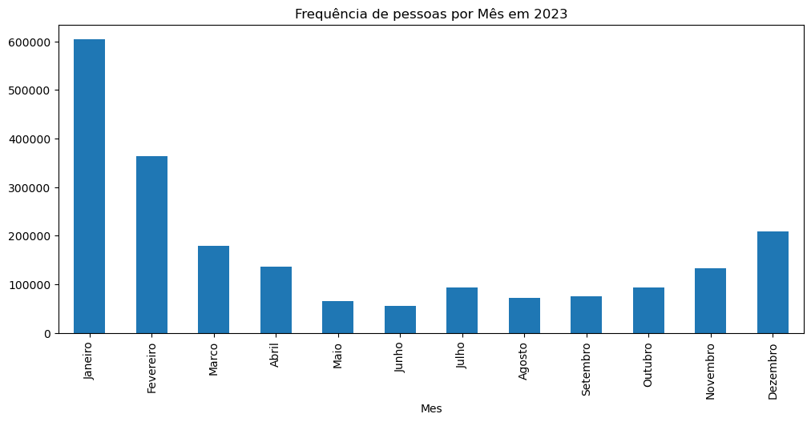

```python
df_sul_2023 = df_sul[df_sul['Ano'] == 2023]
ordem_meses = [
    "Janeiro", "Fevereiro", "Marco", "Abril", "Maio", "Junho",
    "Julho", "Agosto", "Setembro", "Outubro", "Novembro", "Dezembro"
]
quant_mes = df_sul_2023.groupby("Mes", observed=True)['Chegadas'].sum()
#Orderna os index da serie com base no vetor ordem_MESES
quant_mes.index = pd.CategoricalIndex(quant_mes.index, categories=ordem_meses, ordered=True)
quant_mes = quant_mes.sort_index()

quant_mes.plot(kind = 'bar', figsize=(12,5))
plt.title("Frequência de pessoas por Mês em 2023")
```

Os meses de verão tem um grande fluxo de turistas, diferente dos meses de inverno. Como a maior parte dos turistas são da América do Sul e normalmente as férias mais longas são no verão, isso possívelmente representa alguma relação.

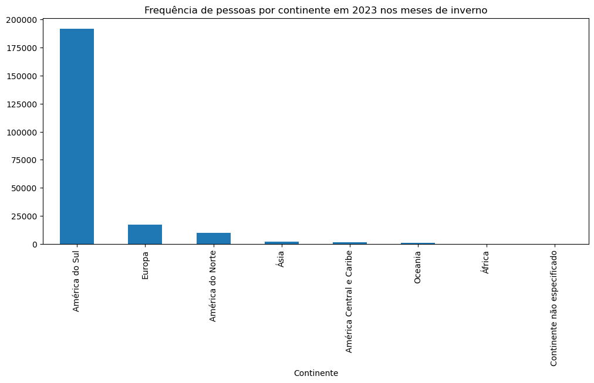

```python
df_sul_2023_inv = df_sul_2023[df_sul_2023['Mes'].isin(meses_inverno)]
df_sul_2023_inv.groupby("Continente", observed=True)['Chegadas'].sum().sort_values(ascending=False).head(10).plot(kind = "bar", figsize=(12,5))
plt.title("Frequência de pessoas por continente em 2023 nos meses de inverno")
```

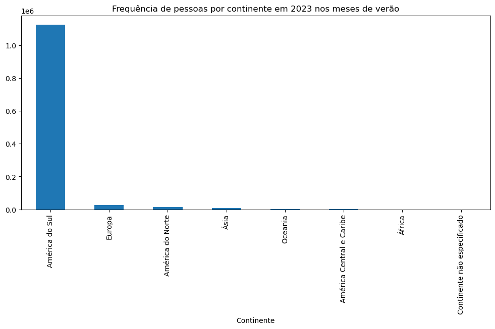

```python
df_sul_2023_ver = df_sul_2023[df_sul_2023['Mes'].isin(meses_verao)]
df_sul_2023_ver.groupby("Continente", observed=True)['Chegadas'].sum().sort_values(ascending=False).head(10).plot(kind = "bar", figsize=(12,5))
plt.title("Frequência de pessoas por continente em 2023 nos meses de verão")
```